# p8130_homework1_lq2250

Lanlan_Qing

2024-09-14

This is homework 1 of Biostatistics P8130  
The solutions are as follows:

# Problem 1

## Codings

```r
# Set score variable of bike crash
score_1 = c(45, 39, 25, 47, 49, 5, 70, 99, 74, 37, 99, 35, 8, 59)
score_sample = data.frame(score_1)
# Compute descriptive data of the first sample (bike crash)
mean_score1 = mean(score_1)
median_score1 = median(score_1)
range_score1 = max(score_1)-min(score_1)
sd_score1 = sd(score_1)
summary(score_1)
```

```
##    Min. 1st Qu.  Median    Mean 3rd Qu.    Max.
##    5.00   35.50   46.00   49.36   67.25   99.00
```

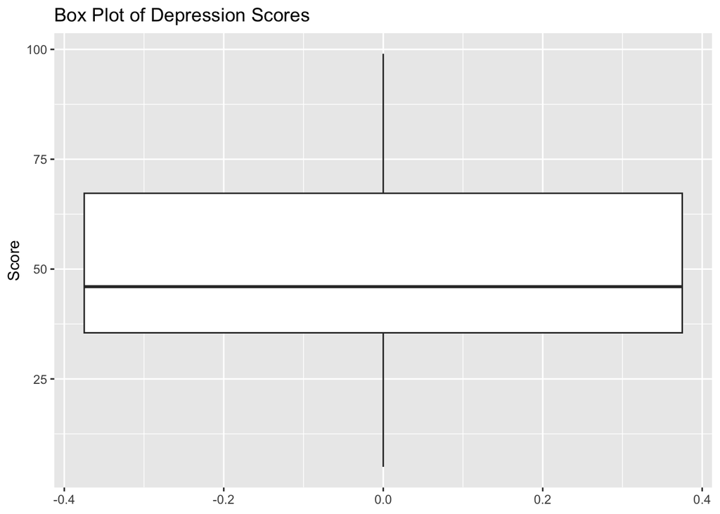

```r
#Create box plot
library(ggplot2)
ggplot(score_sample, aes(y = score_1))+
  geom_boxplot()+
  labs(title = 'Box Plot of Depression Scores',
       y = 'Score')
```

## Answers

**(a)** **Mean** = 49.36; **Median** = 46; **Range** = 94; **SD** = 28.85  
**(b)** 1.According to the box plot and summary:

- Minimum( the lower bound of whisker): 5
- Q1(the lower bound of the box): 35.5
- Median: 46
- Q3(the upper bound of the box): 67.25
- Maximum (the upper bound of whisker): 99

2.Distribution Description:

- Score mean = 49 is higher than median = 46, indicating mean on the right side of the median. High values pull the distribution to the right side
- Most data are concentrated on the lower half (on the left side of the median)
- Suggest a right-skewed, non-symmetric and unimodal distribution

# Problem 2

## Codings

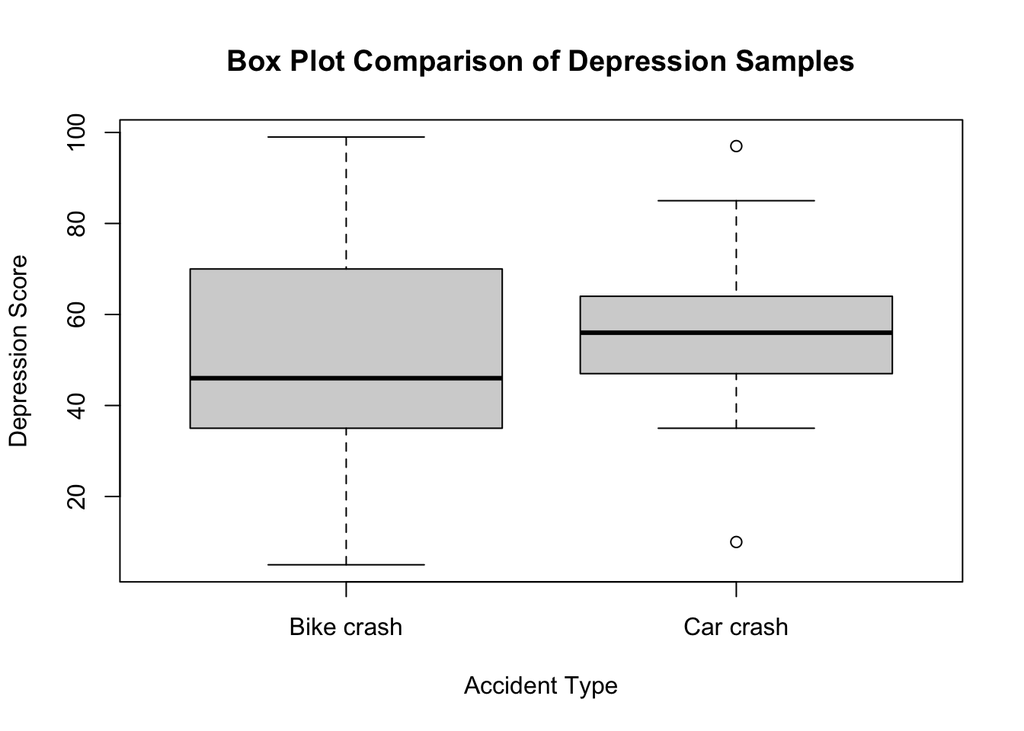

```r
# Set Set score variable of car crash
score_2 = c(67, 50, 85, 43, 64, 35, 47, 97, 58, 58, 10, 56, 50)

# Create a list of data used for creating box plot
depression_data = list('Bike crash' = score_1,
            'Car crash' = score_2)

# Create a side-by-side box plot of samples
box_plot_comparison = boxplot(depression_data, main = 'Box Plot Comparison of Depression Samples',
        xlab = 'Accident Type',
        ylab = 'Depression Score')
```

```r
# Make a table of two sets of results
table_box_plot = cbind(summary(score_1), summary(score_2))
table_box_plot
```

```
##             [,1]     [,2]
## Min.     5.00000 10.00000
## 1st Qu. 35.50000 47.00000
## Median  46.00000 56.00000
## Mean    49.35714 55.38462
## 3rd Qu. 67.25000 64.00000
## Max.    99.00000 97.00000
```

## Answers

**Description of box plots:**

**Description of the underlying distribution:**

1.For bike crash accident:

- It follows a right-skewed, non-symmetric and unimodal distribution without any outliers.

# Problem 3

## Answers

**(a)** A = {2,4,6,8,10,12}  
P(A) = 6/12 = 1/2  
**(b)** B = {10}  
P(B) = 1/12  
**(c)** Since B is the subset of A  
P(BUA) = P(A) = 1/2  
**(d)** P(A intersect B) = P(A) + P(B) - P(AUB) = 1/2 + 1/12 - 1/2 = 1/12  
P(A)P(B) = 1/2*1/12 is not equal to 1/12, thus A and B are not independent.

# Problem 4

## Answers

According to the text: P(de) = 0.05; P(+|de) = 0.8; P(+|no de) = 0.1

## Codings

```r
p_de = 0.8*0.05/(0.8*0.05+0.1*0.95)
```

P(de|+) = [P(+|de)*P(de)]/[P(+|de)*P(de)+P(+|no de)*P(no de)] = 0.2962963